# Synopsis

# Overview

Central Limit Theorum (for our purposes) states that distribution of averages of iid variables, properly normalized, becomes that of a standard normal as the sample size increases.

Exponential distribution is the “continous” counterpart of geometric distribution. It describes the time between events in a Poisson Process. So if \(\lambda\) is the rate parameter associated with Poisson distrbution, exponential distribution function for expoential distibution is \(P(x) = \lambda e^{-\lambda x}\). The expected value E[X] or the mean of an exponential distributed random variable is \({\frac{1}{\lambda}}\) and its Variance \(V[X] = \frac{1}{\lambda ^{2}}\). So the standard deviation is same as mean.

# Simulations

```r
set.seed(3)
lambda <- 0.2 #Set the lambda to 0.2 as required for this exercise
sample.size <- 50
no.of.simulations <- 1000
# Generate 40,000 exponential distributed numbers, distrbute them into a matrix of size 1000 x 40
simulated <- matrix(rexp(no.of.simulations*sample.size, rate=lambda), no.of.simulations, sample.size)
row.Means = rowMeans(simulated) # averages of sample of 40 calcualted for each of 1000 rows
```

# Results

## Sample Mean versus Theoratical Mean

The Theoratical mean for the sampling distribution of averages is still centered at the population mean = \(frac{1}{\lambda}\).

```r
mu <- 1/lambda; mu;
```

```
## [1] 5
```

```r
observed.mean <- mean(row.Means); observed.mean;
```

```
## [1] 4.997669
```

[figure not shown]

```r
hist(row.Means, prob=T, col="yellow", xlab="Sample Mean",
          ylab="Density", main="Figure-1: Distribution of Averages of 1000 samples \nof size 40 drawn from exponentially distributed Population (Rate = 2)",
          breaks=50)
rug(row.Means)
#Plot the theoratical mean and the distribution
abline(v=mu, col="blue", lty=2, lwd=3)
x.Fit <- seq(min(row.Means), max(row.Means), length=50)
y.Fit <- dnorm(x.Fit, mean=mu, sd=(1/lambda/sqrt(sample.size)))
lines(x.Fit, y.Fit, col="blue", lty=2, pch=21)

#Plot the observed
abline(v=observed.mean, col="red", lty=1, lwd=3)
lines(density(row.Means), col="red", lty=1)

legend('topright', c("simulation", "theoretical"), lty=c(1,2), col=c("red", "blue"))
```

## Sample Variance versus Theoratical Variance

The theoratical variance of the sampling distribution of means of sample size \(n\) is given by \({\frac{\sigma^{2}}{n}}\). Here \(\sigma^{2}\) is \(\frac{1}{\lambda ^{2}}\).

```r
theoratical.variance=1/(lambda^2)/sample.size
theoratical.variance
```

```
## [1] 0.5
```

```r
observed.variance=var(row.Means)
observed.variance
```

```
## [1] 0.4866057
```

## Is the sampling Distribution of Means Normal?

To show that the sampling distribution of the means is normal, we can have a look at the distribution of observed (Simulated) data in Figure-1 shown earlier. It looks somewhat normal

Apart from that, we can also demonstrate the same using normal probability plots which compare the observed versus theoratical quantiles.

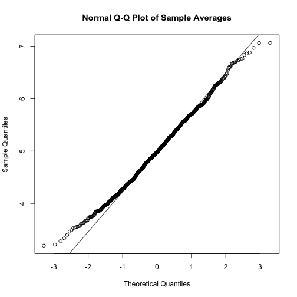

```r
qqnorm(row.Means, main="Normal Q-Q Plot of Sample Averages"); qqline(row.Means);
```

Again the output seems to suggest some ambiguity in lower and upper quartiles.

We also confirm the normality using Shapiro-Wilk Normality Test

```r
shapiro.test(row.Means)
```

```
##
##  Shapiro-Wilk normality test
##
## data:  row.Means
## W = 0.9959, p-value = 0.009312
```

The shapiro-Wilk normality test assume a null hypothesis of data coming from normal and the low p-value seems to negate the Null Hypothesis that data is normal.

We can run some quick tests to see if increasing the sample size will make shapiro-wilk report a statistically significant p-value which can allow us to conclude that sampling distribution of means is coming from normally distributed data.

Following are the numbers reported for some larger sample size.

```r
set.seed(3)
sample.sizes = c(40,50,60,70,80,90,100,120,150,200)
for (i in sample.sizes) {
    simulated <- matrix(rexp(no.of.simulations*i, rate=lambda), no.of.simulations, i)
    row.Means <- rowMeans(simulated)
    t<- shapiro.test(row.Means)
    cat("Sample Size = ", i, "p-Value for Normality Shapiro Wilks= ", t$p.value, "\n" )
}
```

```
## Sample Size =  40 p-Value for Normality Shapiro Wilks=  0.0007348222
## Sample Size =  50 p-Value for Normality Shapiro Wilks=  0.000322532
## Sample Size =  60 p-Value for Normality Shapiro Wilks=  0.06177817
## Sample Size =  70 p-Value for Normality Shapiro Wilks=  0.0001424101
## Sample Size =  80 p-Value for Normality Shapiro Wilks=  0.0004966392
## Sample Size =  90 p-Value for Normality Shapiro Wilks=  0.6924742
## Sample Size =  100 p-Value for Normality Shapiro Wilks=  0.213554
## Sample Size =  120 p-Value for Normality Shapiro Wilks=  0.08502921
## Sample Size =  150 p-Value for Normality Shapiro Wilks=  0.0009915018
## Sample Size =  200 p-Value for Normality Shapiro Wilks=  0.1442366
```